# Solutions to Chapter 5 Exercises

Howard Baek

Last compiled on September 08, 2021

### 5.4.1 Exercises

1. What binwidth tells you the most interesting story about the distribution of `carat`?

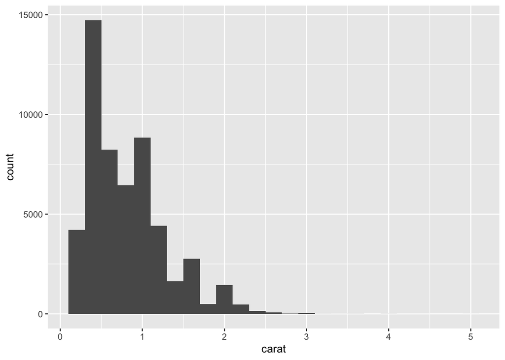

```r
diamonds %>%
  ggplot(aes(carat)) +
  geom_histogram(binwidth = 0.2)
```

- I would go with 0.2 since it gives you the right amount of information about the distribution of `carat`. It tells you it is right skewed.
2. Draw a histogram of `price`. What interesting patterns do you see?

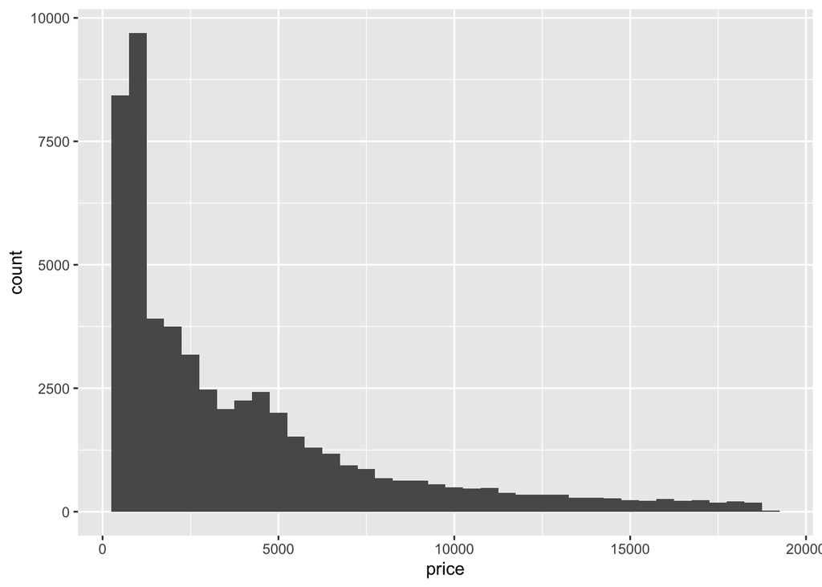

```r
diamonds %>%
  ggplot(aes(price)) +
  geom_histogram(binwidth = 500)
```

- It’s skewed to the right with a long tail.
3. How does the distribution of `price` vary with `clarity`?

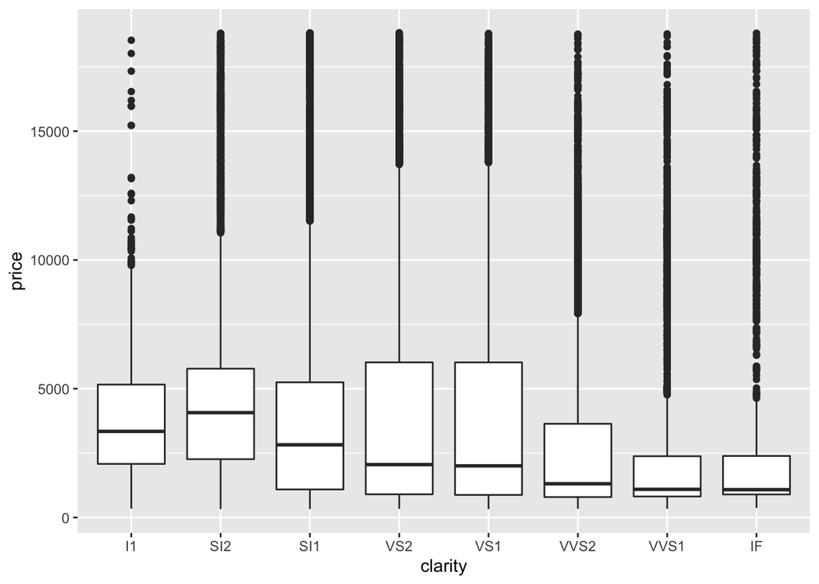

```r
diamonds %>%
  ggplot(aes(clarity, price)) +
  geom_boxplot()
```

- Even though the range of prices is similar across clarity, the median price and IQR of diamonds varies greatly with clarity.
4. Overlay a frequency polygon and density plot of `depth`. What computed variable do you need to map to `y` to make the two plots comparable? (You can either modify `geom_freqpoly()` or `geom_density()`.)

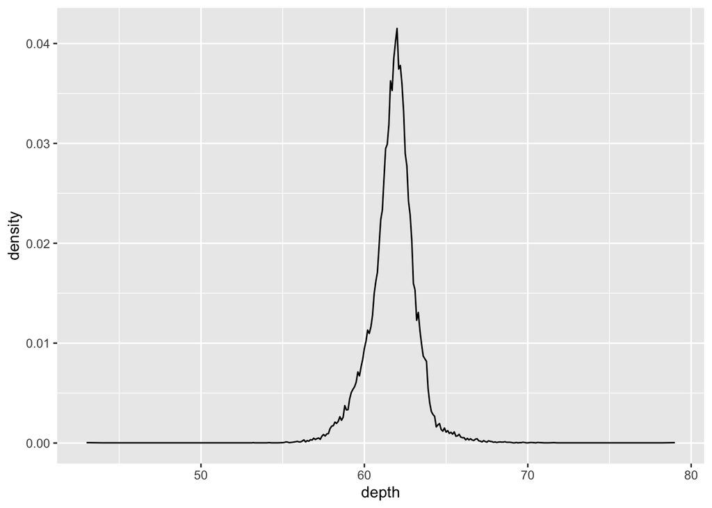

```r
diamonds %>%
  count(depth) %>%
  mutate(sum = sum(n),
         density = n / sum) %>%
  ggplot(aes(depth, density)) +
  geom_line()
```

- Say you start off with the count of values in `depth` and you plot `geom_freqpoly()`. Then, you would want to divide each count by the total number of points to get density. This would get you the y variable needed for `geom_density()`